# Investigating Significance II: v3

Ben Wheeler

April 6, 2017

## Purpose

The purpose of this document is to make progress in determining significance of Twitter Percentages for Republicans. This analysis uses a different data structure than we have been using, it takes advantage of using each candidate as a single observation, but treats all candidates in all counties as a population. There are 62 counties in New York, of them all of them had tweets that were placed within their boundaries. This dataset includes 62 observations for each candidate. One observation for each county. Thus the republican dataset includes 186 observations.

## Determine ability to use Linear Regression

##### Assumptions are as follows:

- Linear relationship
- Multivariate normality
- No or little multicollinearity
- No auto-correlation
- Homoscedasticity

Also there is a rule of thumb of 20 records in order to conduct linear regression. http://www.statisticssolutions.com/assumptions-of-linear-regression/

http://www.sthda.com/english/wiki/correlation-test-between-two-variables-in-r - Checking the Correlation between two variables, how do I test the correlation… - potentially use rank() to rank and then do a rho or a spearman correlation.

#### Read in file

```r
d3 <- read.table("C:/Temp/FINAL_INPUTS/Box Sync/R/v3/v3_AllTags_002_AllSources_analysis_v3_310.csv",
                 header=TRUE, sep=",", na.strings="NA", dec=".", strip.white=TRUE)
```

#### Subset Republicans

The below code subsets the candidates for plotting and additional testing.

```r
RepTKC <- subset(d3,d3$CANDIDATE == 'TRUMP' | d3$CANDIDATE == 'KASICH' | d3$CANDIDATE == 'CRUZ')
RepTK  <- subset(d3,d3$CANDIDATE == 'TRUMP'  | d3$CANDIDATE == 'KASICH')
RepCK  <- subset(d3,d3$CANDIDATE == 'KASICH' | d3$CANDIDATE == 'CRUZ')
RepTC  <- subset(d3,d3$CANDIDATE == 'TRUMP'  | d3$CANDIDATE == 'CRUZ')
RepT <- subset(d3,d3$CANDIDATE == 'TRUMP')
RepK <- subset(d3,d3$CANDIDATE == 'KASICH')
RepC <- subset(d3,d3$CANDIDATE == 'CRUZ')
```

#### Define Function to Print out Statistics and Plot Data

```r
gloop <- function(n,data.in,subset1,subset2,subset3,label.main,label.X, label.Y){
    RegModel.Model <- lm(Candidate_VS~data.in[,n], data=data.in)
    Test <- summary(RegModel.Model)
    Coef  <- Test[4]
    rvals <- c(Test[9],Test[8])
    xlim <- c(0,1)
    ylim <- c(0,1)
      plot(subset1$Candidate_VS,subset1[,n],xlim=xlim, ylim=ylim, col='Blue',
           xlab=label.X,
           ylab =label.Y,
           main = label.main)
      points(subset2$Candidate_VS,subset2[,n],xlim=xlim, ylim=ylim, col='Green')
      points(subset3$Candidate_VS,subset3[,n],xlim=xlim, ylim=ylim, col='Red')
      legend("right",
             legend=c("Trump", "Kasich","Cruz"),
                col=c("blue","Green","red"),
                pch=1, cex=0.8, inset =.01, box.lty=1)
      var1 <- substr(toString(rvals[2]),1,5)
      var2 <- substr(toString(rvals[1]),1,5)
      text(0.95,0.05,label=paste("R2:",var1))
      text(0.923,0.1,label=paste("R2_adj:",var2))
    return(list(
      stats=c(Coef,rvals),
      model=RegModel.Model
    ))
}
gloop2 <- function(n,data.in,subset1,subset2,label.main,label.X, label.Y,cand1,cand2){
    RegModel.Model <- lm(Candidate_VS~data.in[,n], data=data.in)
    Test <- summary(RegModel.Model)
    Coef  <- Test[4]
    rvals <- c(Test[9],Test[8])
    xlim <- c(0,1)
    ylim <- c(0,1)
      plot(subset1$Candidate_VS,subset1[,n],xlim=xlim, ylim=ylim, col='Blue',
           xlab=label.X,
           ylab =label.Y,
           main = label.main)
      points(subset2$Candidate_VS,subset2[,n],xlim=xlim, ylim=ylim, col='Red')
      legend("right",
             legend=c(cand1, cand2),
                col=c("blue","red"),
                pch=1, cex=0.8, inset =.01, box.lty=1)
      var1 <- substr(toString(rvals[2]),1,5)
      var2 <- substr(toString(rvals[1]),1,5)
      text(0.95,0.05,label=paste("R2:",var1))
      text(0.923,0.1,label=paste("R2_adj:",var2))
    return(list(
      stats=c(Coef,rvals),
      model=RegModel.Model
    ))
}
```

# Outcomes

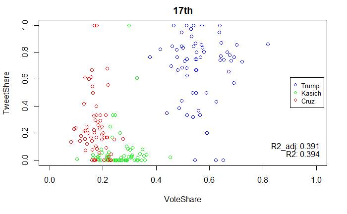

```r
d17 <- gloop(111,RepTKC,RepT,RepK,RepC,"17th","VoteShare","TweetShare")
```

```r
d17$stats
```

```
$coefficients
              Estimate Std. Error  t value     Pr(>|t|)
(Intercept)  0.2220156 0.01441670 15.39989 6.401662e-35
data.in[, n] 0.3339533 0.03048262 10.95553 7.998697e-22

$adj.r.squared
[1] 0.3914946

$r.squared
[1] 0.3947838
```

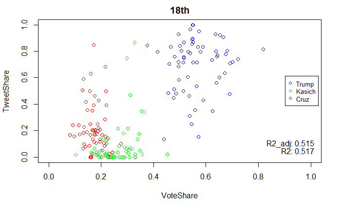

```r
d18 <- gloop(112,RepTKC,RepT,RepK,RepC,"18th","VoteShare","TweetShare")
```

```r
d18$stats
```

```
$coefficients
              Estimate Std. Error  t value     Pr(>|t|)
(Intercept)  0.1996585 0.01318399 15.14401 3.612929e-34
data.in[, n] 0.4010246 0.02853413 14.05421 5.933485e-31

$adj.r.squared
[1] 0.5150985

$r.squared
[1] 0.5177196
```

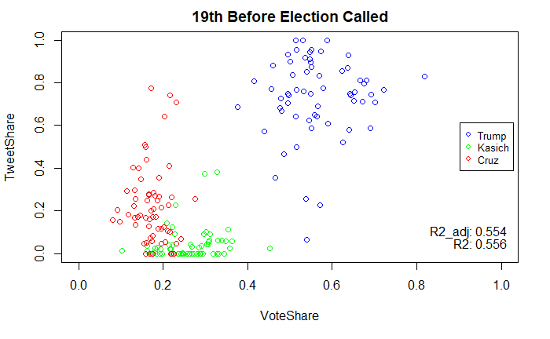

```r
d19b4 <- gloop(113,RepTKC,RepT,RepK,RepC,"19th Before Election Called","VoteShare","TweetShare")
```

```r
d19b4$stats
```

```
$coefficients
              Estimate Std. Error  t value    Pr(>|t|)
(Intercept)  0.1998255 0.01239817 16.11734 5.11010e-37
data.in[, n] 0.4005234 0.02634437 15.20338 2.41731e-34

$adj.r.squared
[1] 0.5543702

$r.squared
[1] 0.556779
```

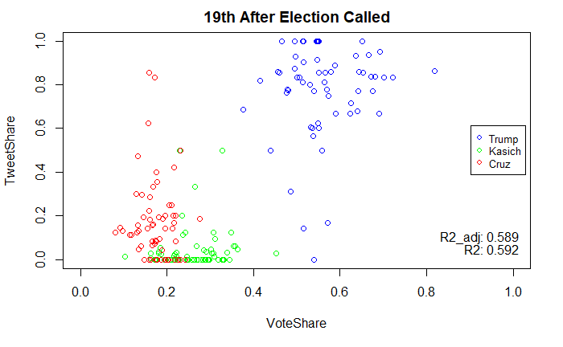

```r
d19aft <- gloop(114,RepTKC,RepT,RepK,RepC,"19th After Election Called","VoteShare","TweetShare")
```

```r
d19aft$stats
```

```
$coefficients
              Estimate Std. Error  t value     Pr(>|t|)
(Intercept)  0.2069062 0.01148551 18.01454 3.153110e-42
data.in[, n] 0.3792813 0.02339434 16.21252 4.266325e-37

$adj.r.squared
[1] 0.5899477

$r.squared
[1] 0.5922007
```

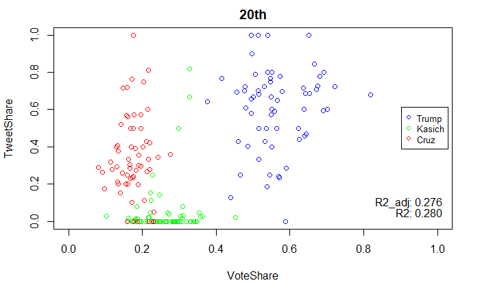

```r
d20 <- gloop(115,RepTKC,RepT,RepK,RepC,"20th","VoteShare","TweetShare")
```

```r
d20$stats
```

```
$coefficients
              Estimate Std. Error   t value     Pr(>|t|)
(Intercept)  0.2279397 0.01669993 13.649142 9.380656e-30
data.in[, n] 0.3161810 0.03730092  8.476493 7.368258e-15

$adj.r.squared
[1] 0.2769227

$r.squared
[1] 0.2808312
```

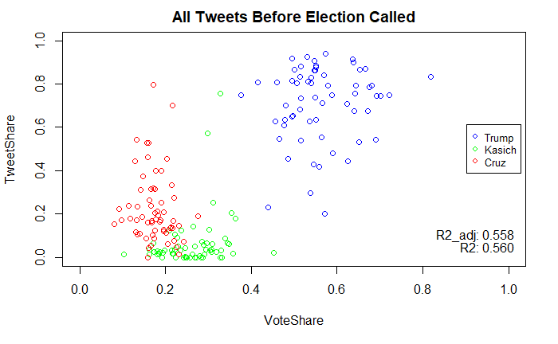

```r
db4 <- gloop(116,RepTKC,RepT,RepK,RepC,"All Tweets Before Election Called","VoteShare","TweetShare")
```

```r
db4$stats
```

```
$coefficients
              Estimate Std. Error  t value     Pr(>|t|)
(Intercept)  0.1918211 0.01269708 15.10750 4.626249e-34
data.in[, n] 0.4245367 0.02770504 15.32345 1.073084e-34

$adj.r.squared
[1] 0.5582702

$r.squared
[1] 0.560658
```

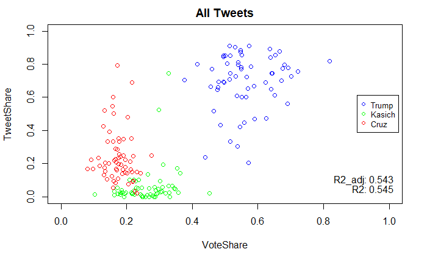

```r
dall <- gloop(117,RepTKC,RepT,RepK,RepC,"All Tweets","VoteShare","TweetShare")
```

```r
dall$stats
```

```
$coefficients
              Estimate Std. Error  t value     Pr(>|t|)
(Intercept)  0.1902139 0.01308145 14.54073 2.164801e-32
data.in[, n] 0.4293583 0.02887337 14.87039 2.307768e-33

$adj.r.squared
[1] 0.5433548

$r.squared
[1] 0.5458232
```

# Trump and Kasich Only

This section looks at R-squared values for TweetShare vs. VoteShare after removing Cruz.

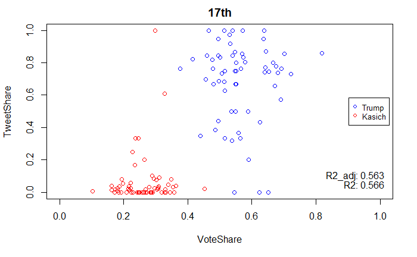

```r
d17 <- gloop2(111,RepTK,RepT,RepK,"17th","VoteShare","TweetShare","Trump","Kasich")
```

```r
d17$stats
```

```
$coefficients
              Estimate Std. Error  t value     Pr(>|t|)
(Intercept)  0.2859803 0.01414881 20.21232 9.414937e-41
data.in[, n] 0.3382727 0.02676383 12.63918 6.379858e-24

$adj.r.squared
[1] 0.5634409

$r.squared
[1] 0.5669902
```

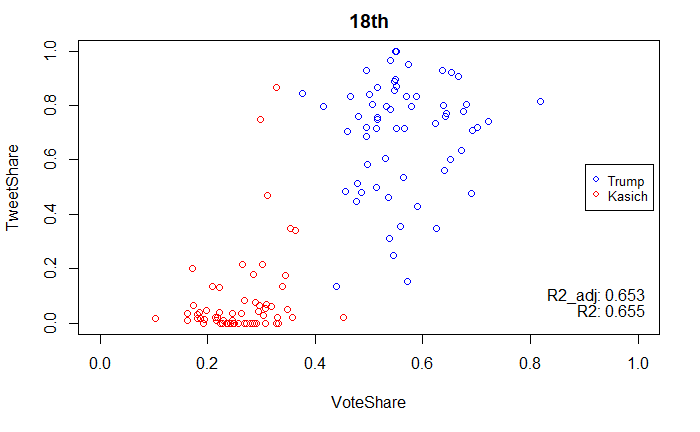

```r
d18 <- gloop2(112,RepTK,RepT,RepK,"18th","VoteShare","TweetShare","Trump","Kasich")
```

```r
d18$stats
```

```
$coefficients
              Estimate Std. Error  t value     Pr(>|t|)
(Intercept)  0.2650983 0.01314728 20.16373 1.180869e-40
data.in[, n] 0.3789428 0.02484599 15.25167 4.791803e-30

$adj.r.squared
[1] 0.6531434

$r.squared
[1] 0.6559634
```

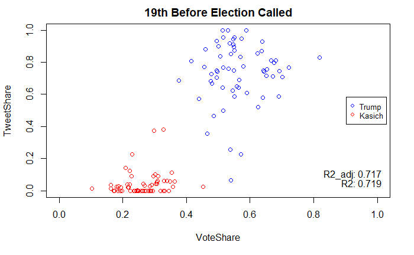

```r
d19b4 <- gloop2(113,RepTK,RepT,RepK,"19th Before Election Called","VoteShare","TweetShare","Trump","Kasich")
```

```r
d19b4$stats
```

```
$coefficients
              Estimate Std. Error  t value     Pr(>|t|)
(Intercept)  0.2657737 0.01155636 22.99805 3.509965e-46
data.in[, n] 0.3787221 0.02141166 17.68766 1.807439e-35

$adj.r.squared
[1] 0.7171459

$r.squared
[1] 0.7194455
```

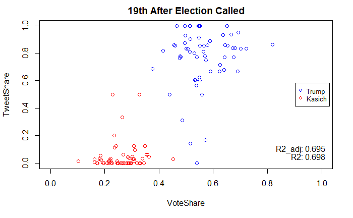

```r
d19aft <- gloop2(114,RepTK,RepT,RepK,"19th After Election Called","VoteShare","TweetShare","Trump","Kasich")
```

```r
d19aft$stats
```

```
$coefficients
              Estimate Std. Error  t value     Pr(>|t|)
(Intercept)  0.2701078 0.01194856 22.60589 4.512853e-45
data.in[, n] 0.3472548 0.02082967 16.67116 5.017446e-33

$adj.r.squared
[1] 0.6959246

$r.squared
[1] 0.6984377
```

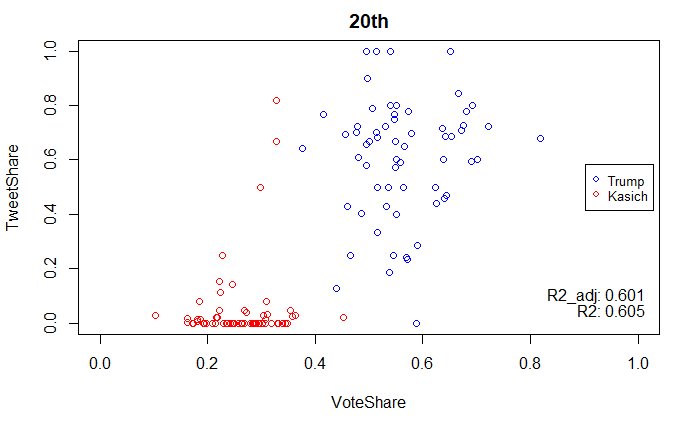

```r
d20 <- gloop2(115,RepTK,RepT,RepK,"20th","VoteShare","TweetShare","Trump","Kasich")
```

```r
d20$stats
```

```
$coefficients
              Estimate Std. Error  t value     Pr(>|t|)
(Intercept)  0.2845236 0.01337184 21.27782 7.057975e-43
data.in[, n] 0.3901483 0.02853999 13.67023 2.269366e-26

$adj.r.squared
[1] 0.601781

$r.squared
[1] 0.6050186
```

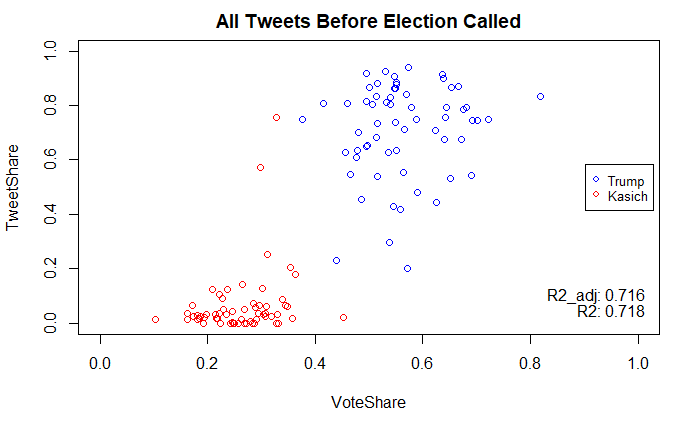

```r
db4 <- gloop2(116,RepTK,RepT,RepK,"All Tweets Before Election Called","VoteShare","TweetShare","Trump","Kasich")
```

```r
db4$stats
```

```
$coefficients
              Estimate Std. Error  t value     Pr(>|t|)
(Intercept)  0.2589390 0.01186165 21.82994 5.908353e-44
data.in[, n] 0.3979108 0.02254861 17.64680 2.215332e-35

$adj.r.squared
[1] 0.7162037

$r.squared
[1] 0.718511
```

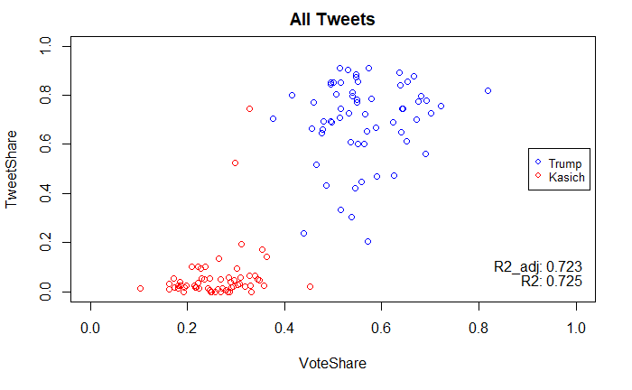

```r
db4 <- gloop2(117,RepTK,RepT,RepK,"All Tweets","VoteShare","TweetShare","Trump","Kasich")
```

```r
db4$stats
```

```
$coefficients
              Estimate Std. Error  t value     Pr(>|t|)
(Intercept)  0.2589296 0.01167315 22.18164 1.240806e-44
data.in[, n] 0.4061782 0.02259747 17.97450 4.356985e-36

$adj.r.squared
[1] 0.7236469

$r.squared
[1] 0.7258936
```

# Trump and Cruz Only

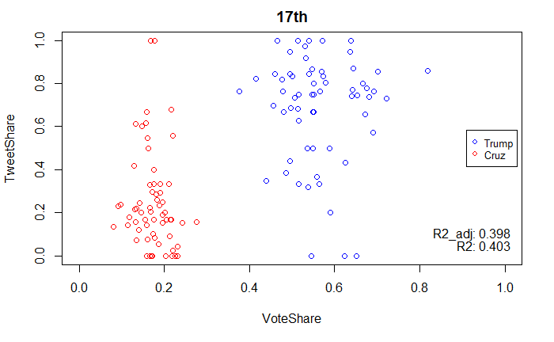

```r
d17 <- gloop2(111,RepTC,RepT,RepC,"17th","VoteShare","TweetShare","Trump","Cruz")
```

```r
d17$stats
```

```
$coefficients
              Estimate Std. Error  t value     Pr(>|t|)
(Intercept)  0.1792964 0.02530145 7.086408 9.652338e-11
data.in[, n] 0.4054302 0.04465175 9.079828 2.360732e-15

$adj.r.squared
[1] 0.3983661

$r.squared
[1] 0.4032575
```

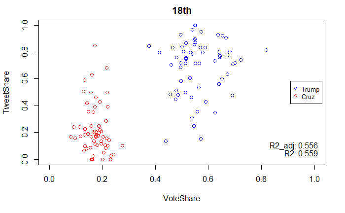

```r
d18 <- gloop2(112,RepTC,RepT,RepC,"18th","VoteShare","TweetShare","Trump","Cruz")
```

```r
d18$stats
```

```
$coefficients
              Estimate Std. Error   t value     Pr(>|t|)
(Intercept)  0.1395534 0.02213003  6.306066 4.765935e-09
data.in[, n] 0.5003081 0.04016728 12.455614 1.754773e-23

$adj.r.squared
[1] 0.5561847

$r.squared
[1] 0.5597929
```

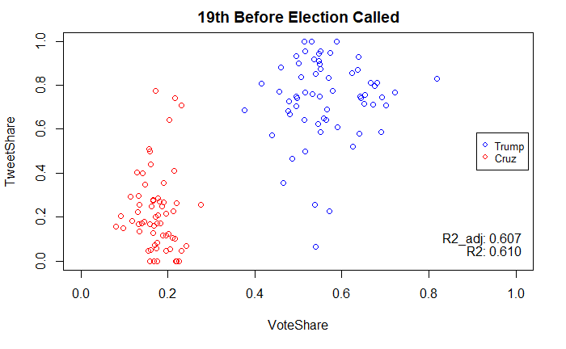

```r
d19b4 <- gloop2(113,RepTC,RepT,RepC,"19th Before Election Called","VoteShare","TweetShare","Trump","Cruz")
```

```r
d19b4$stats
```

```
$coefficients
              Estimate Std. Error   t value     Pr(>|t|)
(Intercept)  0.1252717 0.02105549  5.949597 2.639907e-08
data.in[, n] 0.5082529 0.03673480 13.835734 9.253681e-27

$adj.r.squared
[1] 0.6075648

$r.squared
[1] 0.6107553
```

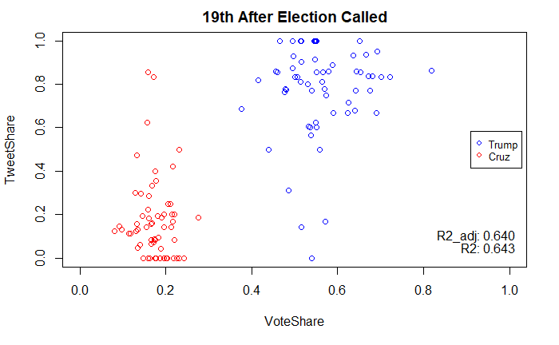

```r
d19aft <- gloop2(114,RepTC,RepT,RepC,"19th After Election Called","VoteShare","TweetShare","Trump","Cruz")
```

```r
d19aft$stats
```

```
$coefficients
              Estimate Std. Error   t value     Pr(>|t|)
(Intercept)  0.1502742 0.01853414  8.107964 4.981792e-13
data.in[, n] 0.4571831 0.03108963 14.705326 1.278630e-28

$adj.r.squared
[1] 0.6401451

$r.squared
[1] 0.6431191
```

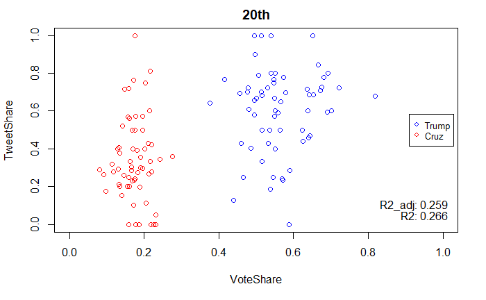

```r
d20 <- gloop2(115,RepTC,RepT,RepC,"20th","VoteShare","TweetShare","Trump","Cruz")
```

```r
d20$stats
```

```
$coefficients
              Estimate Std. Error  t value     Pr(>|t|)
(Intercept)  0.1707812 0.03373157 5.062947 1.480507e-06
data.in[, n] 0.4176224 0.06280521 6.649486 8.773912e-10

$adj.r.squared
[1] 0.2599976

$r.squared
[1] 0.2660138
```

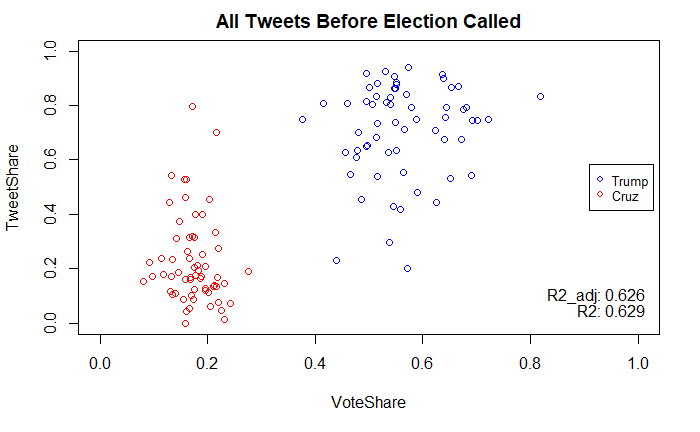

```r
db4 <- gloop2(116,RepTC,RepT,RepC,"All Tweets Before Election Called","VoteShare","TweetShare","Trump","Cruz")
```

```r
db4$stats
```

```
$coefficients
              Estimate Std. Error   t value     Pr(>|t|)
(Intercept)  0.1096509 0.02122080  5.167143 9.399507e-07
data.in[, n] 0.5532605 0.03839226 14.410728 4.181845e-28

$adj.r.squared
[1] 0.6268986

$r.squared
[1] 0.6299319
```

[figure not shown]

```r
db4 <- gloop2(85,RepTC,RepT,RepC,"All Tweets","VoteShare","TweetShare","Trump","Cruz")
```

```r
db4$stats
```

```
$coefficients
                Estimate Std. Error    t value     Pr(>|t|)
(Intercept)  0.364396844 0.05434815 6.70486198 6.654202e-10
data.in[, n] 0.007155119 0.08673504 0.08249398 9.343891e-01

$adj.r.squared
[1] -0.008140486

$r.squared
[1] 5.577768e-05
```

# Kasich and Cruz Only

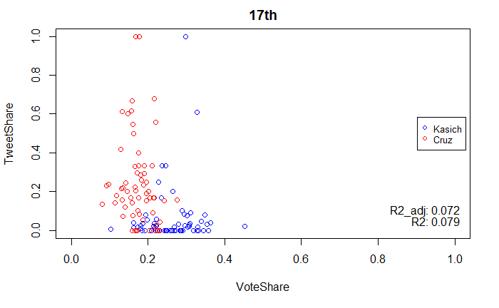

```r
d17 <- gloop2(111,RepCK,RepK,RepC,"17th","VoteShare","TweetShare","Kasich","Cruz")
```

```r
d17$stats
```

```
$coefficients
                Estimate  Std. Error  t value     Pr(>|t|)
(Intercept)   0.23255458 0.007356145 31.61365 1.301585e-60
data.in[, n] -0.09015958 0.027707905 -3.25393 1.472807e-03

$adj.r.squared
[1] 0.07231465

$r.squared
[1] 0.0798568
```

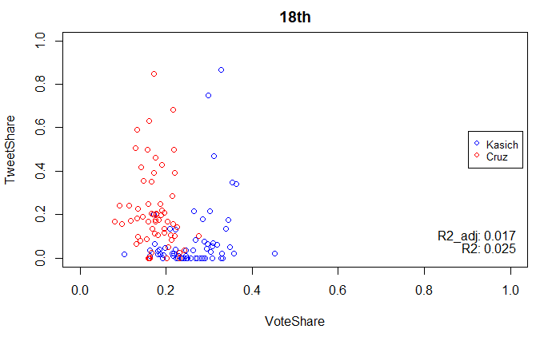

```r
d18 <- gloop2(112,RepCK,RepK,RepC,"18th","VoteShare","TweetShare","Kasich","Cruz")
```

```r
d18$stats
```

```
$coefficients
               Estimate  Std. Error   t value     Pr(>|t|)
(Intercept)   0.2273176 0.007901011 28.770698 3.318236e-56
data.in[, n] -0.0590315 0.033120583 -1.782321 7.718437e-02

$adj.r.squared
[1] 0.01738876

$r.squared
[1] 0.02537747
```

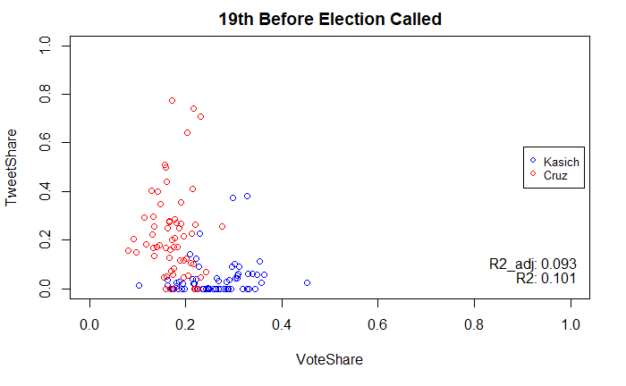

```r
d19b4 <- gloop2(113,RepCK,RepK,RepC,"19th Before Election Called","VoteShare","TweetShare","Kasich","Cruz")
```

```r
d19b4$stats
```

```
$coefficients
               Estimate  Std. Error   t value     Pr(>|t|)
(Intercept)   0.2358195 0.007511783 31.393279 2.785188e-60
data.in[, n] -0.1318913 0.035562316 -3.708738 3.147881e-04

$adj.r.squared
[1] 0.09395426

$r.squared
[1] 0.1013205
```

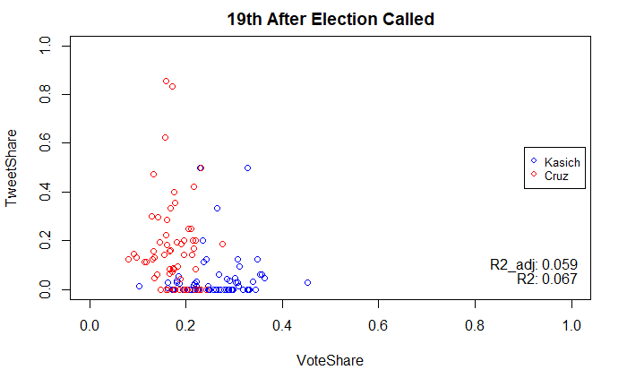

```r
d19aft <- gloop2(114,RepCK,RepK,RepC,"19th After Election Called","VoteShare","TweetShare","Kasich","Cruz")
```

```r
d19aft$stats
```

```
$coefficients
               Estimate  Std. Error   t value     Pr(>|t|)
(Intercept)   0.2313348 0.007361917 31.423167 9.509542e-60
data.in[, n] -0.1102076 0.037445715 -2.943129 3.901531e-03

$adj.r.squared
[1] 0.05955146

$r.squared
[1] 0.06732376
```

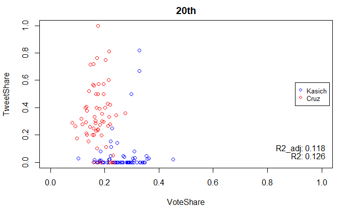

```r
d20 <- gloop2(115,RepCK,RepK,RepC,"20th","VoteShare","TweetShare","Kasich","Cruz")
```

```r
d20$stats
```

```
$coefficients
               Estimate  Std. Error   t value     Pr(>|t|)
(Intercept)   0.2387727 0.007548594 31.631408 1.224405e-60
data.in[, n] -0.1036754 0.024706394 -4.196298 5.177420e-05

$adj.r.squared
[1] 0.1189675

$r.squared
[1] 0.1261303
```

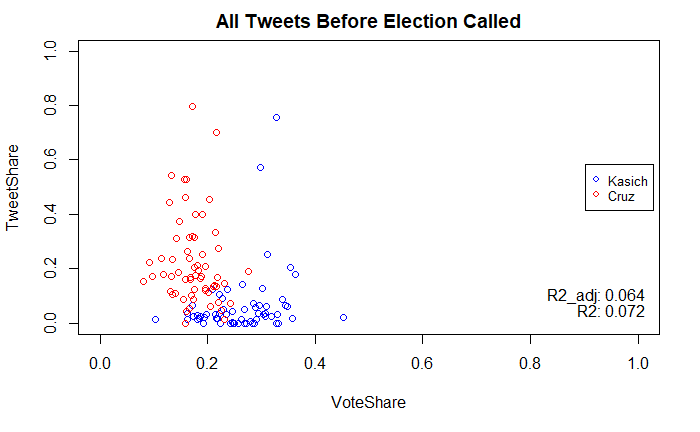

```r
db4 <- gloop2(116,RepCK,RepK,RepC,"All Tweets Before Election Called","VoteShare","TweetShare","Kasich","Cruz")
```

```r
db4$stats
```

```
$coefficients
               Estimate Std. Error   t value     Pr(>|t|)
(Intercept)   0.2345408 0.00792787 29.584335 1.686853e-57
data.in[, n] -0.1118513 0.03623882 -3.086505 2.506854e-03

$adj.r.squared
[1] 0.06482734

$r.squared
[1] 0.07243037
```

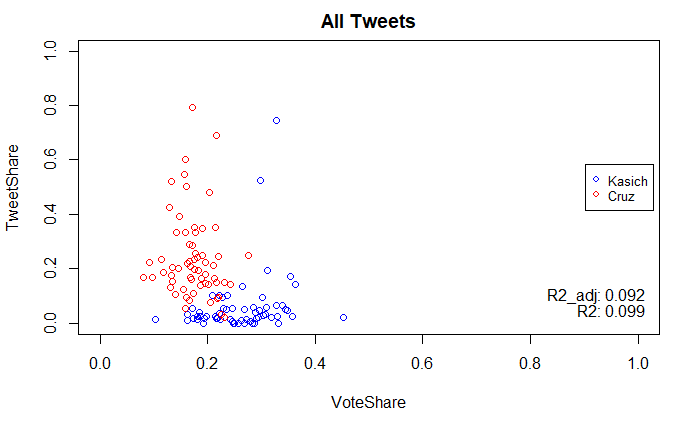

```r
db4 <- gloop2(117,RepCK,RepK,RepC,"All Tweets","VoteShare","TweetShare","Kasich","Cruz")
```

```r
db4$stats
```

```
$coefficients
               Estimate  Std. Error   t value     Pr(>|t|)
(Intercept)   0.2381083 0.007952382 29.941757 4.647265e-58
data.in[, n] -0.1314043 0.035775756 -3.672998 3.571686e-04

$adj.r.squared
[1] 0.09219007

$r.squared
[1] 0.09957064
```

```r
cor(RepTKC$rank_VS,RepTKC$rank_TS19b4, method = 'spearman')
```

```
[1] 0.5043954
```